# Final Tutorial

```python
from IPython.display import Image
from IPython.core.display import display, HTML
```

[figure not shown]

```python
PATH = "/Users/renlihong/fall2019/final tutorial/"
Image(filename = PATH + "chelsea.jpg", width=1920, height=1080)
```

Picture from: [wallpapercave.com](http://wallpapercave.com/).

# What makes a team to win the game in the English Premiere League?

Ruijie Ren

## Introduction

As one of the biggest football leagues in the world, the English Premiere League has always been a joy to watch and every game there would be thousands of fans to be in the stadium and tens of thousands of people watching the game online. From the perspective of a football fan I would always appreciate every player's efforts and those brilliant goals and I would carefully read the game and think about the formation and the tactics, which makes me wondering, what makes a team to win a game in the premiere league?

If you are new to football, then feel free to check out the links below, which give detailed explanation of what happens on the pitch and how the two teams play the game back and forth. In short, there are so many formations and tactics that could be applied to the team and in order to beat our opponent, we have to find out the best solution. People always say that in football the tactics are evolving "spirally", which means there is no strictly dominant strategy in this game. If a team is full of skillful players then it might seem easy for them to take the winning but a relatively less powerful team might give up their possesion of the ball and try counter-attack to win the game.

Interestingly, the English Premiere League was not regarded as a league that could play "beautiful football" as La Liga (the Spanish football league) and in the season of 16-17 a Spanish manager Pep Guardiola arrived at the the Premiere League and began to coach one of the biggest team - Manchester City. He was the one who made the world realize the importance of possession and his team would always keep the ball in their side. Being curious of if Pep Guardiola indeed changed the league, I am going to collect the match data from the Premiere League and try to find the **key factors** for a team to win the game.

### Further Readings

*A review of the 18-19 season: [Premier League 2018-19 review: what we learned tactically from the season](https://www.theguardian.com/football/2019/may/14/premier-league-2018-19-tactical-review-press-and-possess/).

*A website that analyzes every team's tactics: [PREMIER LEAGUE TACTICS](https://eplindex.com/tag/premier-league-tactics/).

*A tactic review of the 18-19 season: [Premier League tactics 2018/19 review: 4-4-2 returns, the power of full-backs and every team assessed](https://www.telegraph.co.uk/football/2019/05/17/premier-league-tactics-201819-review-4-4-2-returns-power-full/).

*A match analysis website: https://totalfootballanalysis.com/.

## Tools & Libraries

Python is a great tool of data analyzing because it has splendid tools and libraries for us to play with the data. This time we will mainly use

- Pandas: https://pandas.pydata.org/
- NumPy: https://numpy.org/
- seaborn: https://seaborn.pydata.org/
- statsmodel: https://www.statsmodels.org/stable/index.html
- scikit-learn: https://scikit-learn.org/stable/

```python
import pandas as pd
import numpy as np
import matplotlib.pyplot as plt
import seaborn as sns
import statsmodels.api as sm
import statsmodels.formula.api as smf
from sklearn import linear_model
from sklearn.ensemble import RandomForestClassifier
from sklearn.model_selection import train_test_split, validation_curve, cross_val_score
```

## Part I: Data Collection

```python
season_1213 = pd.read_csv("1213.csv")
season_1314 = pd.read_csv("1314.csv")
season_1415 = pd.read_csv("1415.csv")
season_1516 = pd.read_csv("1516.csv")
season_1617 = pd.read_csv("1617.csv")
season_1718 = pd.read_csv("1718.csv")
season_1819 = pd.read_csv("1819.csv")
season_1920 = pd.read_csv("1920.csv")
season_1920.head()
```

|  | timestamp | date_GMT | status | attendance | home_team_name | away_team_name | Pre-Match PPG (Home) | Pre-Match PPG (Away) | home_ppg | away_ppg | ... | odds_ft_home_team_win | odds_ft_draw | odds_ft_away_team_win | odds_ft_over15 | odds_ft_over25 | odds_ft_over35 | odds_ft_over45 | odds_btts_yes | odds_btts_no | stadium_name |
| --- | --- | --- | --- | --- | --- | --- | --- | --- | --- | --- | --- | --- | --- | --- | --- | --- | --- | --- | --- | --- | --- |
| 0 | 1565377200 | Aug 9 2019 - 7:00pm | complete | 53333.0 | Liverpool | Norwich City | 0.0 | 0.0 | 3.00 | 0.56 | ... | 1.15 | 9.75 | 19.75 | 1.09 | 1.33 | 1.83 | 2.85 | 1.95 | 1.77 | Anfield (Liverpool) |
| 1 | 1565436600 | Aug 10 2019 - 11:30am | complete | 59870.0 | West Ham United | Manchester City | 0.0 | 0.0 | 0.88 | 2.11 | ... | 12.00 | 6.65 | 1.26 | 1.12 | 1.43 | 2.10 | 3.45 | 1.83 | 1.87 | London Stadium (London) |
| 2 | 1565445600 | Aug 10 2019 - 2:00pm | complete | 10714.0 | AFC Bournemouth | Sheffield United | 0.0 | 0.0 | 1.13 | 1.50 | ... | 2.00 | 3.65 | 3.95 | 1.28 | 1.87 | 3.25 | 6.20 | 1.71 | 2.00 | Vitality Stadium (Bournemouth- Dorset) |
| 3 | 1565445600 | Aug 10 2019 - 2:00pm | complete | 19784.0 | Burnley | Southampton | 0.0 | 0.0 | 1.67 | 1.00 | ... | 2.75 | 3.25 | 2.85 | 1.37 | 2.15 | 3.90 | 7.75 | 1.83 | 1.87 | Turf Moor (Burnley) |
| 4 | 1565445600 | Aug 10 2019 - 2:00pm | complete | 25151.0 | Crystal Palace | Everton | 0.0 | 0.0 | 1.38 | 0.56 | ... | 3.30 | 3.25 | 2.40 | 1.39 | 2.20 | 4.10 | 8.25 | 1.87 | 1.83 | Selhurst Park (London) |

5 rows × 54 columns

The above table is a standard match stat table of the data. I will use the data from the season 12-13 until now because in the earlier seasons the recordings of "possession" are all missing, which will play an important role in our analysis. The tables have many columns and I will pick the most relevant ones to the game:

- timestamp: a timestamp that indicates the match time.
- date_GMT: the kick-off time in Greenwich Mean Time.
- status: a status indicating whether the game is complete or not.
- home_team_name: the name of the home team.
- away_team_name: the name of the away team.
- home_team_goal_count: the goal scored by the home team in the whole game.
- away_team_goal_count: the goal scored by the away team in the whole game.
- home_team_corner_count: the corners kicked by the home team in the whole game.
- away_team_corner_count: the corners kicked by the away team in the whole game.
- home_team_yellow_cards: the number of yellow cards had by the home team in the whole game.
- away_team_yellow_cards: the number of yellow cards had by the away team in the whole game.
- home_team_red_cards: the number of red cards had by the home team in the whole game.
- away_team_red_cards: the number of red cards had by the away team in the whole game.
- home_team_shots: the number of shots by the home team in the whole game.
- away_team_shots: the number of shots by the away team in the whole game.
- home_team_shots_on_target: the number of shots on target by the home team in the whole game.
- away_team_shots_on_target: the number of shots on target by the away team in the whole game.
- home_team_fouls: the number of fouls by the home team in the whole game.
- away_team_fouls: the number of fouls by the away team in the whole game.
- home_team_possession: the possession percent by the home team in the whole game.
- away_team_possession: the possession percent by the away team in the whole game.

## Part II: Data Cleaning & Assembling

Notice that the data of season 19-20 is incomplete and half of the rows have "incomplete" as their value of "status" because now the 19-20 season is ongoing. Thus, we need to drop the rows that has "incomplete" in the "status" column.

```python
indexincomplete = season_1920[ season_1920['status'] == 'incomplete'].index
season_1920.drop(indexincomplete , inplace=True)
season_1920.tail()
```

|  | timestamp | date_GMT | status | attendance | home_team_name | away_team_name | Pre-Match PPG (Home) | Pre-Match PPG (Away) | home_ppg | away_ppg | ... | odds_ft_home_team_win | odds_ft_draw | odds_ft_away_team_win | odds_ft_over15 | odds_ft_over25 | odds_ft_over35 | odds_ft_over45 | odds_btts_yes | odds_btts_no | stadium_name |
| --- | --- | --- | --- | --- | --- | --- | --- | --- | --- | --- | --- | --- | --- | --- | --- | --- | --- | --- | --- | --- | --- |
| 164 | 1576335600 | Dec 14 2019 - 3:00pm | complete | 30396.0 | Sheffield United | Aston Villa | 1.25 | 0.50 | 1.44 | 0.44 | ... | 1.91 | 3.80 | 4.10 | 1.21 | 1.69 | 2.70 | 4.95 | 1.57 | 2.20 | Bramall Lane (Sheffield) |
| 165 | 1576344600 | Dec 14 2019 - 5:30pm | complete | 27701.0 | Southampton | West Ham United | 0.88 | 1.13 | 0.78 | 1.33 | ... | 1.95 | 3.85 | 3.80 | 1.19 | 1.61 | 2.50 | 4.45 | 1.53 | 2.30 | St. Mary's Stadium (Southampton- Hampshire) |
| 166 | 1576418400 | Dec 15 2019 - 2:00pm | complete | 63328.0 | Manchester United | Everton | 1.88 | 0.50 | 1.78 | 0.56 | ... | 1.67 | 4.00 | 5.45 | 1.25 | 1.77 | 2.95 | 5.60 | 1.74 | 1.95 | Old Trafford (Manchester) |
| 167 | 1576418400 | Dec 15 2019 - 2:00pm | complete | 31674.0 | Wolverhampton Wanderers | Tottenham Hotspur | 1.63 | 0.75 | 1.44 | 1.00 | ... | 2.90 | 3.60 | 2.45 | 1.25 | 1.80 | 3.00 | 5.70 | 1.61 | 2.15 | Molineux Stadium (Wolverhampton- West Midlands) |
| 168 | 1576427400 | Dec 15 2019 - 4:30pm | complete | 60031.0 | Arsenal | Manchester City | 1.63 | 2.00 | 1.44 | 2.11 | ... | 6.75 | 5.80 | 1.41 | 1.09 | 1.32 | 1.80 | 2.80 | 1.48 | 2.45 | Emirates Stadium (London) |

5 rows × 54 columns

Notice that the data is placed in the order of timestamp and the above few rows show the tail of the 19-20 season's table. Since the status are all "complete", it means we have dropped the belowing rows that the matches are not played yet.

```python
season_1213['date_GMT'] = "12-13"
season_1314['date_GMT'] = "13-14"
season_1415['date_GMT'] = "14-15"
season_1516['date_GMT'] = "15-16"
season_1617['date_GMT'] = "16-17"
season_1718['date_GMT'] = "17-18"
season_1819['date_GMT'] = "18-19"
season_1920['date_GMT'] = "19-20"
season_1213.head()
```

|  | timestamp | date_GMT | status | attendance | home_team_name | away_team_name | Pre-Match PPG (Home) | Pre-Match PPG (Away) | home_ppg | away_ppg | ... | odds_ft_home_team_win | odds_ft_draw | odds_ft_away_team_win | odds_ft_over15 | odds_ft_over25 | odds_ft_over35 | odds_ft_over45 | odds_btts_yes | odds_btts_no | stadium_name |
| --- | --- | --- | --- | --- | --- | --- | --- | --- | --- | --- | --- | --- | --- | --- | --- | --- | --- | --- | --- | --- | --- |
| 0 | 1345298400 | 12-13 | complete | 60078 | Arsenal | Sunderland | 0.0 | 0.0 | 2.00 | 0.84 | ... | 1.35 | 5.25 | 9.99 | 0.0 | 0.0 | 0.0 | 0.0 | 0.0 | 0.0 | Emirates Stadium |
| 1 | 1345298400 | 12-13 | complete | 25062 | Fulham | Norwich City | 0.0 | 0.0 | 1.26 | 0.68 | ... | 1.90 | 3.67 | 4.51 | 0.0 | 0.0 | 0.0 | 0.0 | 0.0 | 0.0 | Craven Cottage |
| 2 | 1345298400 | 12-13 | complete | 18072 | Queens Park Rangers | Swansea City | 0.0 | 0.0 | 0.74 | 1.05 | ... | 2.35 | 3.42 | 3.31 | 0.0 | 0.0 | 0.0 | 0.0 | 0.0 | 0.0 | Loftus Road Stadium |
| 3 | 1345298400 | 12-13 | complete | 23973 | Reading | Stoke City | 0.0 | 0.0 | 1.05 | 0.74 | ... | 2.62 | 3.31 | 2.97 | 0.0 | 0.0 | 0.0 | 0.0 | 0.0 | 0.0 | Madejski Stadium |
| 4 | 1345298400 | 12-13 | complete | 26039 | West Bromwich Albion | Liverpool | 0.0 | 0.0 | 1.63 | 1.47 | ... | 3.93 | 3.51 | 2.08 | 0.0 | 0.0 | 0.0 | 0.0 | 0.0 | 0.0 | The Hawthorns (West Bromwich) |

5 rows × 54 columns

For the potential use that in the future we might need to catagorizes the data by the season, we change the GMT time to one single value, indicating which season the table is showing.

```python
season_1920[['home_team_fouls', 'away_team_fouls']].tail()
```

|  | home_team_fouls | away_team_fouls |
| --- | --- | --- |
| 164 | -1 | -1 |
| 165 | -1 | -1 |
| 166 | -1 | -1 |
| 167 | -1 | -1 |
| 168 | -1 | -1 |

Notice that even after we dropped the unplayed matches of the 19-20 season, there are still some rows that have the "-1" value. Since we are looking at the data of real world football game, the number of fouls can not be negative. It indicates that the piece of information is missing and it works the same as the "NaN" value, therefore we need to drop them.

However, in order to drop the rows that have the "-1" value, if we process the data one by one it would be exhausting and unefficient. Thus we need to define a function that does the job. At the same time, we want this function to concate the dataframes, since we have several seasons' data and it would be easy for us to manipulate the data if we can aggregate them in a single table.

Also, since the dataset does not have a column that indicates the result of the match, we have to add it manually. If you are not familiar with football, a winning team can have 3 points and the losing team get 0 point. If two teams are draw, then each team gets 1 point. Last, our function will also **slice** a single game to 2 rows, since one game (which is a single row) is played by 2 teams, this row actually provides 2 pieces of information of the match.

```python
# our processing function, it takes a list of data (which is a list of seasons)
# and it combines the seasons into 1 single table
# it will clean the data by drop the rows that have value "-1"
# it also computes the result of every match and assign each team the points they get
# then it slice one single row to two rows since one game is played by
# two teams and it actually stores two pieces of information.
def process_data(list):
    # here we only take the necessary columns such as goals, shots...
    column_list = ['timestamp','date_GMT','home_team_name','away_team_name','home_team_goal_count','away_team_goal_count','home_team_corner_count','away_team_corner_count','home_team_yellow_cards','home_team_red_cards','away_team_yellow_cards','away_team_red_cards','home_team_shots','away_team_shots','home_team_shots_on_target','away_team_shots_on_target','home_team_fouls','away_team_fouls','home_team_possession','away_team_possession']
    # it combines the list of the data
    data = pd.concat(list)
    data = data[column_list]
    # we compute the result of the game and assign the point to the team
    data.loc[data['home_team_goal_count'] > data['away_team_goal_count'], 'home_team_point'] = 3
    data.loc[data['home_team_goal_count'] == data['away_team_goal_count'], 'home_team_point'] = 1
    data.loc[data['home_team_goal_count'] < data['away_team_goal_count'], 'home_team_point'] = 0
    data.loc[data['home_team_goal_count'] > data['away_team_goal_count'], 'away_team_point'] = 0
    data.loc[data['home_team_goal_count'] == data['away_team_goal_count'], 'away_team_point'] = 1
    data.loc[data['home_team_goal_count'] < data['away_team_goal_count'], 'away_team_point'] = 3
    # we slice one row to two rows
    home_team_list = ['timestamp','date_GMT','home_team_name','home_team_point','home_team_goal_count','home_team_corner_count','home_team_yellow_cards','home_team_red_cards','home_team_shots','home_team_shots_on_target','home_team_fouls','home_team_possession']
    away_team_list = ['timestamp','date_GMT','away_team_name','away_team_point','away_team_goal_count','away_team_corner_count','away_team_yellow_cards','away_team_red_cards','away_team_shots','away_team_shots_on_target','away_team_fouls','away_team_possession']
    home_team_data = data[home_team_list]
    away_team_data = data[away_team_list]
    # in order to join the two slices, we rename them
    home_team_data = home_team_data.rename(columns={"home_team_name": "team_name", "date_GMT":"season", "home_team_point": "point", "home_team_goal_count": "goal_count", "home_team_corner_count": "corner_count", "home_team_yellow_cards": "yellow_cards", "home_team_red_cards": "red_cards", "home_team_shots": "shots", "home_team_shots_on_target": "shots_on_target", "home_team_fouls": "fouls", "home_team_possession": "possession"})
    away_team_data = away_team_data.rename(columns={"away_team_name": "team_name", "date_GMT":"season", "away_team_point": "point", "away_team_goal_count": "goal_count", "away_team_corner_count": "corner_count", "away_team_yellow_cards": "yellow_cards", "away_team_red_cards": "red_cards", "away_team_shots": "shots", "away_team_shots_on_target": "shots_on_target", "away_team_fouls": "fouls", "away_team_possession": "possession"})
    data = pd.concat([home_team_data, away_team_data], axis=0)
    # here we also assign a catagorical data of "win/draw/lose"
    data.loc[data['point'] == 3, 'result'] = "win"
    data.loc[data['point'] == 1, 'result'] = "draw"
    data.loc[data['point'] == 0, 'result'] = "lose"
    # here we drop the rows that have the "-1" value
    index_to_remove = data[(data['corner_count'] == -1) | (data['yellow_cards'] == -1) | (data['red_cards'] == -1) | (data['shots'] == -1) | (data['shots_on_target'] == -1) | (data['fouls'] == -1) | (data['possession'] == -1)].index
    data.drop(index_to_remove , inplace=True)
    return data
```

Once the helper function is ready to use we can start to process our data by just calling it on a list.

The main table will be all the seasons available, which is from season1213 to season 1920 and the list will contain all the data files. We'll name it as "data".

Also, if you remember, at the introduction I mentioned that in the season of 16-17 a Spanish manager Pep Guardiola came to the Premier League and he is the one who shocked the world by his tactic of keeping ball possession. So we are also going to split the seasons by two parts, the first one is from 12-13 to 15-16, the second one is from 16-17 until now. They are called "old_data" and "new_data" respectively.

```python
season_list = [season_1213,season_1314,season_1415,season_1516,season_1617,season_1718,season_1819,season_1920]
before_pep_list = [season_1213,season_1314,season_1415,season_1516]
after_pep_list = [season_1617,season_1718,season_1819,season_1920]
data = process_data(season_list)
old_data = process_data(before_pep_list)
new_data = process_data(after_pep_list)
```

## Part III: Data Graphing & Analyzing

After processing the data, we can start to graph the data. By visualizing the data we can try to find some intuitive relations between the match stats.

Let's start with a simple one, below is the scatter plot with a regression line of goal vs shots. Intuitively, if a team makes more shots, then it is more likely for them to have a goal.

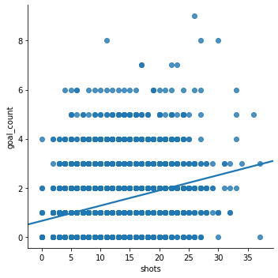

```python
sns.lmplot(x ="shots", y ="goal_count", data = data, order = 1, ci = None)
```

As can be seen from the regression line, the more shots we make, the more goals we have, and it makes sense.

So what about goals vs shots_on_target?

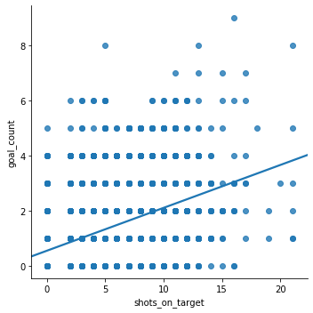

```python
sns.lmplot(x ="shots_on_target", y ="goal_count", data = data, order = 1, ci = None)
```

As the regression line shows, same story happens here. The more shots on target, the more goals we have.

Then what about possession? This might not be as intuitively clear as above.

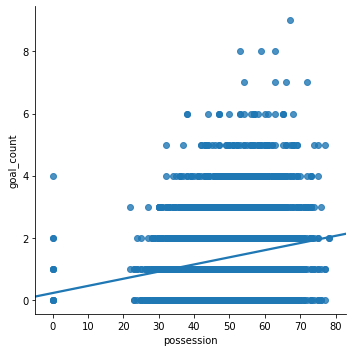

```python
sns.lmplot(x ="possession", y ="goal_count", data = data, order = 1, ci = None)
```

If we add a regression line to the graph that goals vs possession, then the trend is still increasing, which means when we have more ball control, we are more likely to have a goal.

You might have noticed that, the first two graphs we make, one is of shots and one is of shots_on_target, the two variables are similiar and behave almost the same. Yes, these two variables indeed have high relations, let's add regression line to them to see what happens.

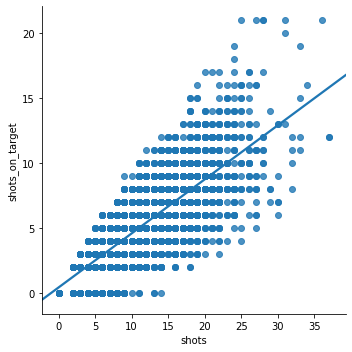

```python
sns.lmplot(x ="shots", y ="shots_on_target", data = data, order = 1, ci = None)
```

As can be seen from the picture, the scatter plot is aggregated together and these two variables do have a high relation, which means if we want to make a model to predict the game, we would use **one of them** because they are highly related.

Then let's plot some other variables to see if there is relation between them.

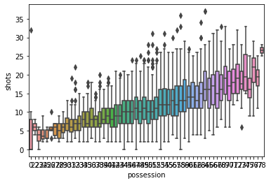

```python
sns.boxplot(x='possession', y = 'shots', data=data)
```

The above is the box plot of shots vs possession. Roughly speaking, when the team has more possession, they will have more shots. This makes sense because when we have more ball control we can have more chances to shoot.

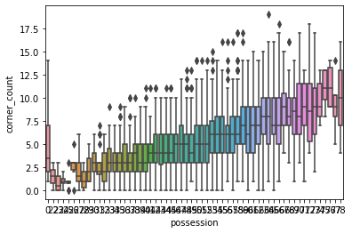

```python
sns.boxplot(x='possession', y = 'corner_count', data=data)
```

The above is a boxplot of corner count vs possession. It also shows a positive relation. Is it because when we have more possession, we would have more shots, then we would have more corner? Let's plot corner vs shots.

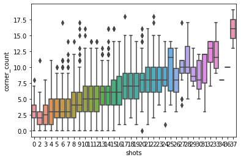

```python
sns.boxplot(x='shots', y = 'corner_count', data=data)
```

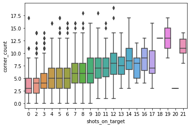

```python
sns.boxplot(x='shots_on_target', y = 'corner_count', data=data)
```

Then, let's have a look at fouls with other stats.

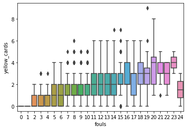

```python
sns.boxplot(x='fouls', y = 'yellow_cards', data=data)
```

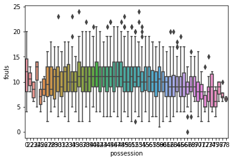

```python
sns.boxplot(x='possession', y = 'fouls', data=data)
```

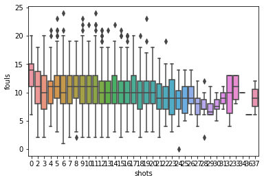

```python
sns.boxplot(x='shots', y = 'fouls', data=data)
```

Then, we have seen most of the match stats and their relations. To come back to our main topic, we can draw the data based on the result, to see what makes the difference between the winning team and the losing team.

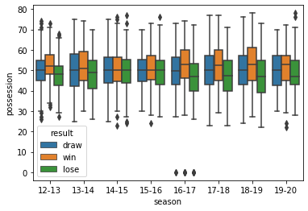

```python
sns.boxplot(x='season', y = 'possession', hue = 'result',data=data)
```

As can be seen from above, the winning team will have more possession than the losing team. Thus "possession" will be our key factor of the model.

## Part IV: Regression

After exploring out the relations between the match stats, we can start to make our regression model. Since to win a game we need goals, and goals have high positive relation with shots and possession, then our model will be **point = a *shots + b* possession + c**

```python
res = smf.ols(formula='point ~ shots + possession', data=data).fit()
print(res.summary())
```

```
                            OLS Regression Results
==============================================================================
Dep. Variable:                  point   R-squared:                       0.059
Model:                            OLS   Adj. R-squared:                  0.059
Method:                 Least Squares   F-statistic:                     151.8
Date:                Mon, 16 Dec 2019   Prob (F-statistic):           1.18e-64
Time:                        12:03:52   Log-Likelihood:                -8056.3
No. Observations:                4826   AIC:                         1.612e+04
Df Residuals:                    4823   BIC:                         1.614e+04
Df Model:                           2
Covariance Type:            nonrobust
==============================================================================
                 coef    std err          t      P>|t|      [0.025      0.975]
------------------------------------------------------------------------------
Intercept      0.2720      0.096      2.847      0.004       0.085       0.459
shots          0.0477      0.004     11.888      0.000       0.040       0.056
possession     0.0112      0.002      5.173      0.000       0.007       0.015
==============================================================================
Omnibus:                    30032.458   Durbin-Watson:                   2.011
Prob(Omnibus):                  0.000   Jarque-Bera (JB):              510.423
Skew:                           0.268   Prob(JB):                    1.46e-111
Kurtosis:                       1.499   Cond. No.                         270.
==============================================================================

Warnings:
[1] Standard Errors assume that the covariance matrix of the errors is correctly specified.
```

```python
regression_table = pd.read_html(res.summary().tables[1].as_html(),header=0,index_col=0)[0]
regression_table
```

|  | coef | std err | t | P>\|t\| | [0.025 | 0.975] |
| --- | --- | --- | --- | --- | --- | --- |
| Intercept | 0.2720 | 0.096 | 2.847 | 0.004 | 0.085 | 0.459 |
| shots | 0.0477 | 0.004 | 11.888 | 0.000 | 0.040 | 0.056 |
| possession | 0.0112 | 0.002 | 5.173 | 0.000 | 0.007 | 0.015 |

only possesion

```python
possession_reg_data = smf.ols(formula='point ~ possession', data=data).fit()
print(res.summary())
```

[output not shown]

```python
possession_only_table = pd.read_html(possession_reg_data.summary().tables[1].as_html(),header=0,index_col=0)[0]
possession_only_table
```

|  | coef | std err | t | P>\|t\| | [0.025 | 0.975] |
| --- | --- | --- | --- | --- | --- | --- |
| Intercept | 0.1894 | 0.097 | 1.960 | 0.05 | -0.000023 | 0.379 |
| possession | 0.0239 | 0.002 | 12.556 | 0.00 | 0.020000 | 0.028 |

```python
possession_reg_data_old = smf.ols(formula='point ~ possession', data=old_data).fit()
print(possession_reg_data_old.summary())
```

```
                            OLS Regression Results
==============================================================================
Dep. Variable:                  point   R-squared:                       0.021
Model:                            OLS   Adj. R-squared:                  0.021
Method:                 Least Squares   F-statistic:                     65.51
Date:                Mon, 16 Dec 2019   Prob (F-statistic):           8.27e-16
Time:                        12:03:53   Log-Likelihood:                -5110.8
No. Observations:                3040   AIC:                         1.023e+04
Df Residuals:                    3038   BIC:                         1.024e+04
Df Model:                           1
Covariance Type:            nonrobust
==============================================================================
                 coef    std err          t      P>|t|      [0.025      0.975]
------------------------------------------------------------------------------
Intercept      0.2762      0.138      2.008      0.045       0.007       0.546
possession     0.0219      0.003      8.094      0.000       0.017       0.027
==============================================================================
Omnibus:                    15407.278   Durbin-Watson:                   1.984
Prob(Omnibus):                  0.000   Jarque-Bera (JB):              365.281
Skew:                           0.273   Prob(JB):                     4.79e-80
Kurtosis:                       1.392   Cond. No.                         296.
==============================================================================

Warnings:
[1] Standard Errors assume that the covariance matrix of the errors is correctly specified.
```

```python
possession_only_old_table = pd.read_html(possession_reg_data_old.summary().tables[1].as_html(),header=0,index_col=0)[0]
possession_only_old_table
```

|  | coef | std err | t | P>\|t\| | [0.025 | 0.975] |
| --- | --- | --- | --- | --- | --- | --- |
| Intercept | 0.2762 | 0.138 | 2.008 | 0.045 | 0.007 | 0.546 |
| possession | 0.0219 | 0.003 | 8.094 | 0.000 | 0.017 | 0.027 |

```python
possession_reg_data_new = smf.ols(formula='point ~ possession', data=new_data).fit()
print(possession_reg_data_new.summary())
```

```
                            OLS Regression Results
==============================================================================
Dep. Variable:                  point   R-squared:                       0.045
Model:                            OLS   Adj. R-squared:                  0.044
Method:                 Least Squares   F-statistic:                     102.9
Date:                Mon, 16 Dec 2019   Prob (F-statistic):           1.17e-23
Time:                        12:03:53   Log-Likelihood:                -3706.1
No. Observations:                2202   AIC:                             7416.
Df Residuals:                    2200   BIC:                             7428.
Df Model:                           1
Covariance Type:            nonrobust
==============================================================================
                 coef    std err          t      P>|t|      [0.025      0.975]
------------------------------------------------------------------------------
Intercept      0.1131      0.128      0.881      0.378      -0.139       0.365
possession     0.0256      0.003     10.143      0.000       0.021       0.031
==============================================================================
Omnibus:                    12458.372   Durbin-Watson:                   2.065
Prob(Omnibus):                  0.000   Jarque-Bera (JB):              245.220
Skew:                           0.249   Prob(JB):                     5.64e-54
Kurtosis:                       1.443   Cond. No.                         236.
==============================================================================

Warnings:
[1] Standard Errors assume that the covariance matrix of the errors is correctly specified.
```

## Part V: Conclusion

From our graphing and regression of the data, we see that to win a game, or, to get points, a team have to keep their possession of the ball, also they have to make more shots. Although it seems intuitive, the process that how we approach to this result also matters.